# Netflix Movies and TV Show Analysis

Yao MENG, Hanming ZHANG, Li GUO, Xuqing CHEN

2023-01-18

[figure not shown]

# Introduction about dataset

**About this Dataset:**

Netflix is one of the most popular media and video streaming platforms. They have over 8000 movies or tv shows available on their platform, as of mid-2021, they have over 200M Subscribers globally. This tabular dataset consists of listings of all the movies and tv shows available on Netflix, along with details such as - cast, directors, ratings, release year, duration, etc.

**Data Explanation for Each Column:**

# Presentation and description of the problem

As part of this project, we conducted the following analysis of the Netflix movie and TV show dataset:

Q1 Which countries have been most active in releasing screen shows? How many Movies and TV Shows have been released in each of these countries?

Q2 In recent years, has Netflix focused more on distributing TV Shows or Movies? What is the trend?

Q3 Establish a Youth protection search engine

1. By entering the name of the film/TVshow, we can look up basic information about the film. Parents may be concerned about the suitability of the film for their child, so we have included a note at the end.
2. Make recommendations for films by rating, giving recommendations for films for different age groups, eg: what is the best film for a 12/15 year old to watch

Q4 The most prolific directors, and actors who are associated with most movies

# Data Preparation

```r
# loading packages
library(readr)
library(tidyverse)
library(dplyr)
library(lubridate)
library(ggplot2)

# read and check the data frame
netflix <- read_csv("netflix_titles.csv")
str(netflix)
```

```
## spc_tbl_ [8,807 × 12] (S3: spec_tbl_df/tbl_df/tbl/data.frame)
##  $ show_id     : chr [1:8807] "s1" "s2" "s3" "s4" ...
##  $ type        : chr [1:8807] "Movie" "TV Show" "TV Show" "TV Show" ...
##  $ title       : chr [1:8807] "Dick Johnson Is Dead" "Blood & Water" "Ganglands" "Jailbirds New Orleans" ...
##  $ director    : chr [1:8807] "Kirsten Johnson" NA "Julien Leclercq" NA ...
##  $ cast        : chr [1:8807] NA "Ama Qamata, Khosi Ngema, Gail Mabalane, Thabang Molaba, Dillon Windvogel, Natasha Thahane, Arno Greeff, Xolile "| __truncated__ "Sami Bouajila, Tracy Gotoas, Samuel Jouy, Nabiha Akkari, Sofia Lesaffre, Salim Kechiouche, Noureddine Farihi, G"| __truncated__ NA ...
##  $ country     : chr [1:8807] "United States" "South Africa" NA NA ...
##  $ date_added  : chr [1:8807] "September 25, 2021" "September 24, 2021" "September 24, 2021" "September 24, 2021" ...
##  $ release_year: num [1:8807] 2020 2021 2021 2021 2021 ...
##  $ rating      : chr [1:8807] "PG-13" "TV-MA" "TV-MA" "TV-MA" ...
##  $ duration    : chr [1:8807] "90 min" "2 Seasons" "1 Season" "1 Season" ...
##  $ listed_in   : chr [1:8807] "Documentaries" "International TV Shows, TV Dramas, TV Mysteries" "Crime TV Shows, International TV Shows, TV Action & Adventure" "Docuseries, Reality TV" ...
##  $ description : chr [1:8807] "As her father nears the end of his life, filmmaker Kirsten Johnson stages his death in inventive and comical wa"| __truncated__ "After crossing paths at a party, a Cape Town teen sets out to prove whether a private-school swimming star is h"| __truncated__ "To prote…
##  - attr(*, "spec")=
##   .. cols(
##   ..   show_id = col_character(),
##   ..   type = col_character(),
##   ..   title = col_character(),
##   ..   director = col_character(),
##   ..   cast = col_character(),
##   ..   country = col_character(),
##   ..   date_added = col_character(),
##   ..   release_year = col_double(),
##   ..   rating = col_character(),
##   ..   duration = col_character(),
##   ..   listed_in = col_character(),
##   ..   description = col_character()
##   .. )
##  - attr(*, "problems")=<externalptr>
```

```r
colSums(is.na(netflix))
```

```
##      show_id         type        title     director         cast      country
##            0            0            0         2634          825          831
##   date_added release_year       rating     duration    listed_in  description
##           10            0            4            3            0            0
```

# EDA & Visualization of the data

## Q1 Which countries have been most active in releasing screen shows? How many Movies and TV Shows have been released in each of these countries?

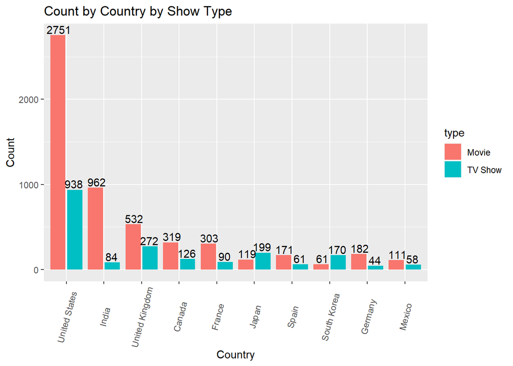

```r
Top_releae_country = netflix %>%
  select(type, country) %>%
  separate_rows(country, sep = ", ") %>%
  rename(Country = country) %>%
  mutate(Country = fct_infreq(Country)) %>%
  group_by(type, Country) %>%
  summarise(Count = n())

#There are many countries, we only look at the top 10 countries with show releases
ggplot(data = Top_releae_country %>% slice(1:10),
       aes(x = Country, y = Count,
           fill = type)) +
  geom_col(position = "dodge2", idth = 0.9) +
  geom_text(aes(label=Count),
            position = position_dodge2(width = 0.8, preserve = 'single'),
            vjust = -0.2, hjust = 0.5)+
  theme(axis.text.x = element_text(angle = 75, hjust = 0.5, vjust = 0.5)) +
  labs(title = "Count by Country by Show Type",
       x = "Country",
       y = "Count")
```

The bar chart clearly shows that the countries with the most releases are the USA (2751 Movies, 938 TV Shows), India (962 Movies, 84 TV Shows) and the UK (532 Movies, 272 TV Shows).

## Q2 In recent years, has Netflix focused more on distributing TV Shows or Movies? What is the trend?

```r
library(reshape2)

head(netflix$date_added[1])
```

```
## [1] "September 25, 2021"
```

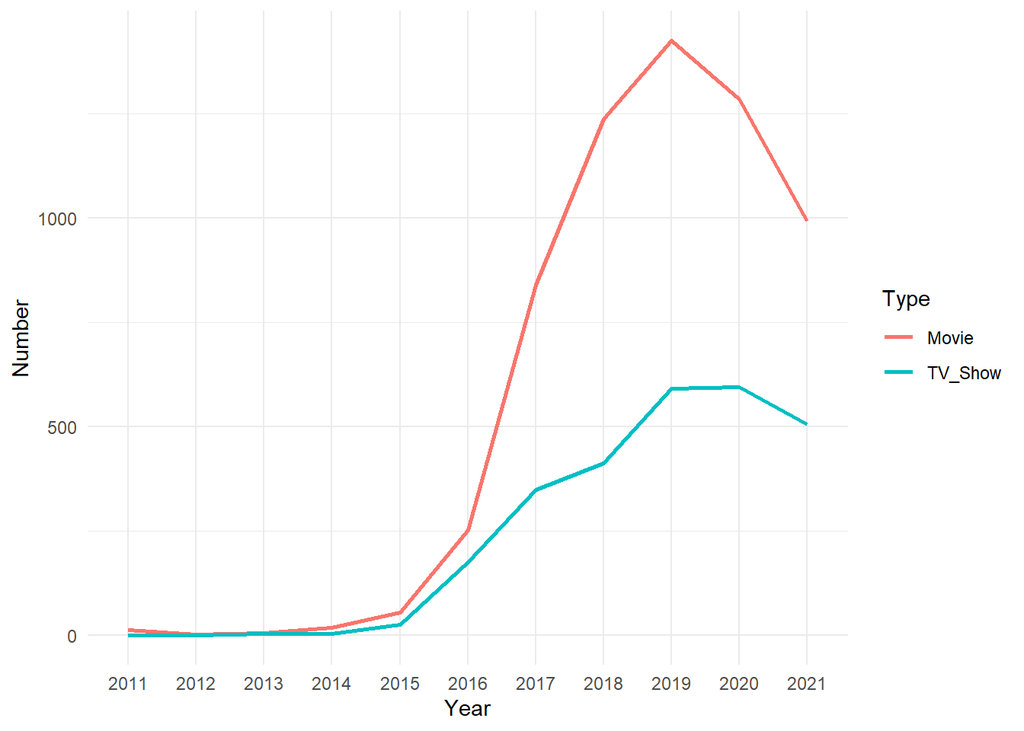

```r
# It shows"September 25, 2021"
# Therefore, the data of 2021 would be incomplete.
# So if we would like to analyse the past 10 years' data, I suggest we analyse from 2010 till now.
# Set MT_Sum as the summary for the total numbers of movie and TV shows from 2010 to 2021(the data of 2021 is incomplete).
# Define MT_Sum as the summarize of movies and TV shows in each year.
netflix <- separate(netflix, date_added, c('month','day','year'), sep=' ')
MT_Sum<-netflix %>%
  group_by(Year=year) %>%
  summarise(Movie = sum(type=="Movie"), TV_Show=sum(type=="TV Show"))%>%
  arrange(desc(Year))%>%
  head(11)

# reshape the data
MT_Sum_Re <- melt(MT_Sum,id="Year")
colnames(MT_Sum_Re) <- c("Year", "Type", "Number")

# plots
MT_Sum_Plot <-ggplot(MT_Sum_Re) +
  aes(x = Year, y = Number, colour = Type, group = Type) +
  geom_line(size = 1) +
  scale_color_hue(direction = 1) +
  theme_minimal()
MT_Sum_Plot
```

The number of movies added is on an upward trend until 2019 and rose significantly between 2015 and 2019, but the number of new movies added has decreased since 2020. Due to the specificity of recent years, we believe that the outbreak of covid-19 has had a huge impact on film production, particularly as the global embargo in 2020 has prevented Netflix from adding more new films.

Overall, we infer that Netflix is more focused on adding movies based on trends before covid-19 starts to impact in 2020.

## Q3 Youth protection search engine

**(1) By entering the name of the film/TVshow, we can look up basic information about the film. Parents may be concerned about the suitability of the film for their child, so we have included a note at the end.**

**(2) Make recommendations for films by rating, giving recommendations for films for different age groups, eg: what is the best film for a 12/15 year old to watch**

```r
#enquiry different ratings level in dataframe
unique(netflix$rating)
```

```
##  [1] "PG-13"    "TV-MA"    "PG"       "TV-14"    "TV-PG"    "TV-Y"
##  [7] "TV-Y7"    "R"        "TV-G"     "G"        "NC-17"    "74 min"
## [13] "84 min"   "66 min"   "NR"       NA         "TV-Y7-FV" "UR"
```

```r
#set a function which could print the basic information by searching the titile of film
Rearch_Title<-function(x){
  result<-
    netflix %>%
    dplyr::filter(title==x) %>%
    select(Title=title,
           Type=type,
           Director=director,
           Release_Year=release_year,
           Duration=duration,
           Rating=rating,
           Category=listed_in,
           Description=description)
  result[is.na(result)] <- 'UNKNOW'

  print(result)

  #set if loop to print different warning message according to the rating
  if(result$Rating=='G'){
    print('This movie is for General Audiences,All Ages Admitted')
  }else if(result$Rating=='PG'){
    print('This movie is Parental Guidance Suggested,Some Material May Not Be Suitable for Children.')
  }else if(result$Rating=='PG-13'){
    print('This movie is Parents Strongly Cautioned, Some Material May Be Inappropriate for Children Under 13')
  }else if(result$Rating=='NC-17'){
    print('This movie is only for Adults over 17')
  }else if(result$Rating=='R'){
    print('This movie is Restricted, Children Under 17 Require Accompanying Parent or Adult Guardian.')
  }else if(result$Rating=='TV-Y'){
    print('This TV Show is for all children')
  }else if(result$Rating=='TV-Y7'){
    print('This TV Show is designed for children age 7 and aboven')
  }else if(result$Rating=='TV-G'){
    print('This TV Show is General Audience')
  }else if(result$Rating=='TV-Y7-FV'){
    print('This TV Show is Directed to Older Children - Fantasy Violence ')
  }else if(result$Rating=='TV-PG'){
    print('This TV Show is  Parental Guidance Suggested ')
  }else if(result$Rating=='TV-14'){
    print('This TV Show ontains some material that unsuitable for children under 14 years of age.  ')
  }else if(result$Rating=='TV-MA'){
    print('This TV Show is specifically designed to be viewed by adults')
  }else
    print('There is no age limit for this movie/TV show')
}


Rearch_Title('Love on the Spectrum')
```

```
## # A tibble: 1 × 8
##   Title                Type    Director Release…¹ Durat…² Rating Categ…³ Descr…⁴
##   <chr>                <chr>   <chr>        <dbl> <chr>   <chr>  <chr>   <chr>
## 1 Love on the Spectrum TV Show UNKNOW        2021 2 Seas… TV-14  Docuse… Findin…
## # … with abbreviated variable names ¹Release_Year, ²Duration, ³Category,
## #   ⁴Description
## [1] "This TV Show ontains some material that unsuitable for children under 14 years of age.  "
```

```r
#create a simple df
agerecom<-
  netflix %>%
  select(Title=title,
         Rating=rating)
head(agerecom)
```

```
## # A tibble: 6 × 2
##   Title                 Rating
##   <chr>                 <chr>
## 1 Dick Johnson Is Dead  PG-13
## 2 Blood & Water         TV-MA
## 3 Ganglands             TV-MA
## 4 Jailbirds New Orleans TV-MA
## 5 Kota Factory          TV-MA
## 6 Midnight Mass         TV-MA
```

```r
#set a function which will reduce the first 2 column of dataframe
reducecolumn<-function(a){
  a<-a[,-c(1:2)]
  return(a)
}

#create 5 separate df according to age
result1<-
  agerecom %>%
  dplyr::filter(Rating %in% c('TV-Y','TV-G','TV-PG','G','PG')) %>%
  mutate(id=row_number(),
         'under7'=Title)
result2<-
  agerecom %>%
  dplyr::filter(Rating %in% c('TV-Y','TV-G','TV-PG','G','PG','TV-Y7','TV-Y7-FV')) %>%
  mutate(id=row_number(),
         'under13'=Title)
result3<-
  agerecom %>%
  dplyr::filter(Rating %in% c('TV-Y','TV-G','TV-PG','G','PG','TV-Y7','TV-Y7-FV','TV-14',
                              'PG-13','R')) %>%
  mutate(id=row_number(),
         'under14'=Title)
result4<-
  agerecom %>%
  dplyr::filter(Rating %in% c('TV-Y','TV-G','TV-PG','G','PG','TV-Y7','TV-Y7-FV','TV-14',
                              'PG-13','R','TV-MA','NC-17')) %>%
  mutate(id=row_number(),
         'under17'=Title)
result5<-
  agerecom %>%
  mutate(id=row_number(),
         'All age'=Title)

#Construct a list containing five data boxes and combine them into one table.
l=list(result1,result2,result3,result4,result5)
l1<-lapply(l, reducecolumn)
df1<-l1%>% reduce(full_join, by = "id")
#the new df only contain 5 column'id','under7','under13','under14','under17','all age'

#Check that the vacant value is correctly filled with NA
colSums(is.na(df1))
```

```
##      id  under7 under13 under14 under17 All age
##       0    7089    6749    3300      90       0
```

```r
#Generate a pie chart by age group
df1
```

```
## # A tibble: 8,807 × 6
##       id under7                                  under13 under14 under17 All a…¹
##    <int> <chr>                                   <chr>   <chr>   <chr>   <chr>
##  1     1 My Little Pony: A New Generation        My Lit… Dick J… Dick J… Dick J…
##  2     2 Confessions of an Invisible Girl        Confes… My Lit… Blood … Blood …
##  3     3 Avvai Shanmughi                         Avvai … The Gr… Gangla… Gangla…
##  4     4 Go! Go! Cory Carson: Chrissy Takes the… Go! Go… The St… Jailbi… Jailbi…
##  5     5 Minsara Kanavu                          Minsar… Confes… Kota F… Kota F…
##  6     6 Jaws                                    Tayo a… Intrus… Midnig… Midnig…
##  7     7 Jaws 2                                  Angry … Monste… My Lit… My Lit…
##  8     8 Jaws 3                                  Chhota… Resurr… Sankofa Sankofa
##  9     9 My Heroes Were Cowboys                  He-Man… Avvai … The Gr… The Gr…
## 10    10 Dharmakshetra                           Jaws    Go! Go… The St… The St…
## # … with 8,797 more rows, and abbreviated variable name ¹`All age`
```

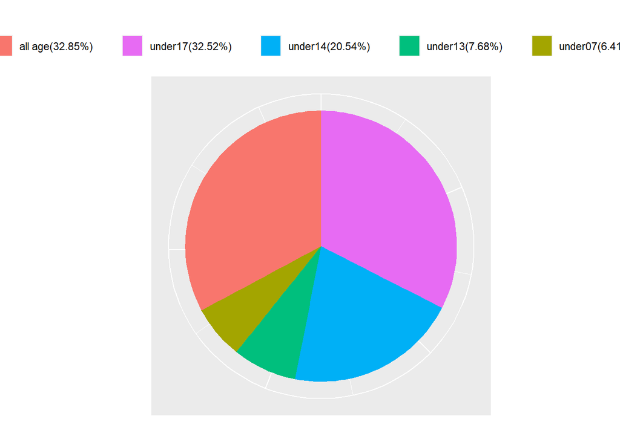

```r
df2<-data_frame(Agegroup = c('under07','under13','under14','under17','all age'),
               Number=c(1718,2058,5507,8717,8807))

df2 = df2[order(df2$Number, decreasing = TRUE),]   # Use order() to sort the data of the data frame from largest to smallest according to the required columns
myLabel = as.vector(df2$Agegroup)
myLabel = paste(myLabel, "(", round(df2$Number / sum(df2$Number) * 100, 2), "%)        ", sep = "")

ggplot(df2, aes(x = "", y = Number, fill = Agegroup)) +
  geom_bar(stat = "identity", width = 1) +
  coord_polar(theta = "y") +
  labs(x = "", y = "", title = "") +
  theme(axis.ticks = element_blank()) +
  theme(legend.title = element_blank(), legend.position = "top") +
  scale_fill_discrete(breaks = df2$Agegroup, labels = myLabel)+
  theme(axis.text.x = element_blank())
```

```r
#Set the function to display different columns according to age
agecheck<-function(a){
  if(a<7){
    df1 %>%
      select('under7')
  }else if(7<a & a<=13){
    df1 %>%
      select('under13')
  }else if(13<a & a<=14){
    df1 %>%
      select('under14')
  }else if(14<a & a<=17){
    df1 %>%
      select('under17')
  }else
    df1 %>%
    select('All age')
}

#test the function
agecheck(12)
```

```
## # A tibble: 8,807 × 1
##    under13
##    <chr>
##  1 My Little Pony: A New Generation
##  2 Confessions of an Invisible Girl
##  3 Avvai Shanmughi
##  4 Go! Go! Cory Carson: Chrissy Takes the Wheel
##  5 Minsara Kanavu
##  6 Tayo and Little Wizards
##  7 Angry Birds
##  8 Chhota Bheem
##  9 He-Man and the Masters of the Universe
## 10 Jaws
## # … with 8,797 more rows
```

```r
agecheck(15)
```

```
## # A tibble: 8,807 × 1
##    under17
##    <chr>
##  1 Dick Johnson Is Dead
##  2 Blood & Water
##  3 Ganglands
##  4 Jailbirds New Orleans
##  5 Kota Factory
##  6 Midnight Mass
##  7 My Little Pony: A New Generation
##  8 Sankofa
##  9 The Great British Baking Show
## 10 The Starling
## # … with 8,797 more rows
```

## Q4 The most prolific directors, and actors who are associated with most movies

```r
#Number of productions produced by each director
Top_dirdecor<-netflix %>%
  group_by(director) %>%
  filter(director !="") %>%
  summarize(Total=n())%>%
  arrange(desc(Total))%>%
  slice(1:10)
Top_dirdecor
```

```
## # A tibble: 10 × 2
##    director               Total
##    <chr>                  <int>
##  1 Rajiv Chilaka             19
##  2 Raúl Campos, Jan Suter    18
##  3 Marcus Raboy              16
##  4 Suhas Kadav               16
##  5 Jay Karas                 14
##  6 Cathy Garcia-Molina       13
##  7 Jay Chapman               12
##  8 Martin Scorsese           12
##  9 Youssef Chahine           12
## 10 Steven Spielberg          11
```

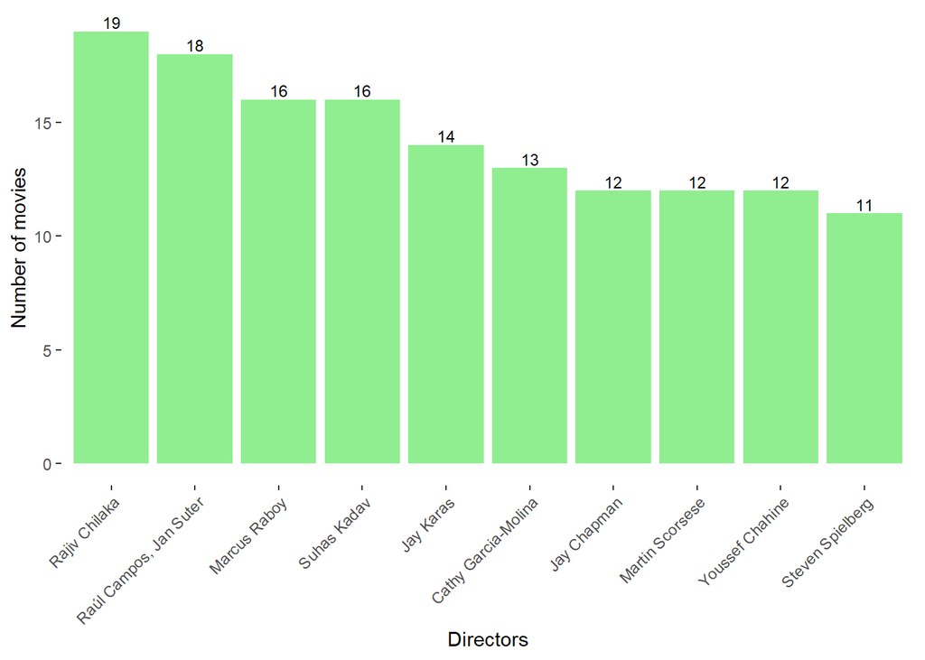

```r
#Visualize data results
ggplot(data=Top_dirdecor %>%
         slice(1:10),mapping =aes(x=reorder(director, - Total),
                                  y=Total)) +
        geom_bar(stat = "identity",width = 0.8,
                 position = position_dodge(width = 0.8)) +
  geom_text(aes(label=Total),
            position = position_dodge(width = 0.9),size=3,vjust=-0.25)+
          geom_col(fill="light green")+
          labs("Top Directors") +
          xlab("Directors")+
          ylab("Number of movies")+
theme(panel.background= element_blank()
      ,plot.title=element_text(30)
      ,axis.title.x=element_text(30)
      ,axis.title.y=element_text(30)
      ,axis.text.x=element_text(20, angle = 45,vjust = 1, hjust = 1)
      ,axis.text.y=element_text(20)
      )
```

```r
#List the actors involved in each film

List_Actors<-netflix %>%
  select(c("show_id","cast","director")) %>%
  gather(key = "role", value = "actor", cast, director) %>%
  filter(actor != "") %>%
  separate_rows(actor, sep = ",")->actorlist
actorlist
```

```
## # A tibble: 71,104 × 3
##    show_id role  actor
##    <chr>   <chr> <chr>
##  1 s2      cast  "Ama Qamata"
##  2 s2      cast  " Khosi Ngema"
##  3 s2      cast  " Gail Mabalane"
##  4 s2      cast  " Thabang Molaba"
##  5 s2      cast  " Dillon Windvogel"
##  6 s2      cast  " Natasha Thahane"
##  7 s2      cast  " Arno Greeff"
##  8 s2      cast  " Xolile Tshabalala"
##  9 s2      cast  " Getmore Sithole"
## 10 s2      cast  " Cindy Mahlangu"
## # … with 71,094 more rows
```

```r
#The number of productions each actor participated in
Count_Actor<- actorlist %>%
  group_by(actor,role) %>%
  summarise(count = n()) %>%
  arrange(desc(count))
Count_Actor
```

```
## # A tibble: 44,416 × 3
## # Groups:   actor [44,170]
##    actor               role  count
##    <chr>               <chr> <int>
##  1 " Anupam Kher"      cast     39
##  2 " Rupa Bhimani"     cast     31
##  3 " Takahiro Sakurai" cast     30
##  4 " Julie Tejwani"    cast     28
##  5 " Om Puri"          cast     27
##  6 " Rajesh Kava"      cast     26
##  7 "Shah Rukh Khan"    cast     26
##  8 " Andrea Libman"    cast     25
##  9 " Boman Irani"      cast     25
## 10 " Paresh Rawal"     cast     25
## # … with 44,406 more rows
```

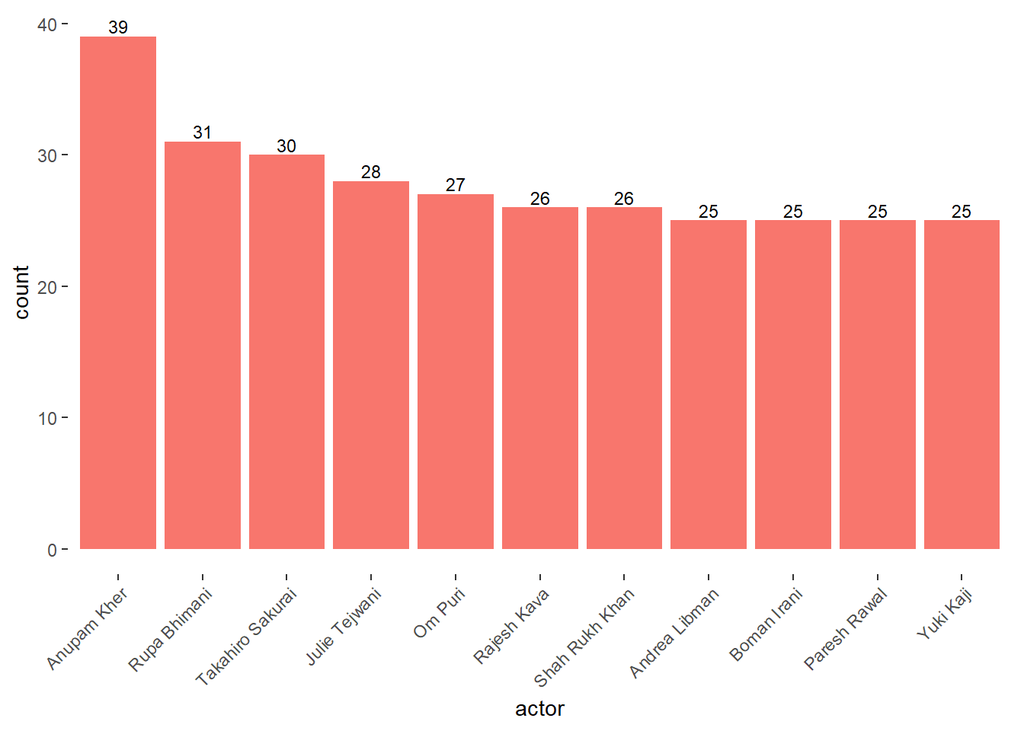

```r
#Visualize data results
Count_Actor %>%
  group_by(role="cast") %>%
  top_n(10,count) %>%
  ungroup() %>%
  ggplot(aes(x = fct_reorder(actor,count,.desc = TRUE), y = count, fill = role)) +
            geom_bar(stat = "identity") +
  geom_text(aes(label=count),
            position = position_dodge(width = 0.9),size=3,vjust=-0.25)+
            theme(legend.position = "none") +
            labs(x = "actor") +
       theme(panel.background= element_blank()
      ,plot.title=element_text(30)
      ,axis.title.x=element_text(30)
      ,axis.title.y=element_text(30)
      ,axis.text.x=element_text(20, angle = 45,vjust = 1, hjust = 1)
      ,axis.text.y=element_text(20)
      )
```

The director with the most Movies and TV Show works is director Rajiv Chilaka, he has produced a total of 19 works. We also list the top ten participating actors who participate the largest number of works. It can be seen that the actor with the largest number of works is Anupam Kher who has participated in 39 Movies and TV Shows works.

# Interpretation / Conclusion

The results of the exploratory data analysis show that, since records began, most of the content on Netflix has come from the United States, India, and the United Kingdom, with the United States contributing significantly to content distribution. For the top 10 countries, the majority of countries released more movies than TV shows.

There was an upward trend in new movies and TV shows added before 2019, but the trend has declined since then. Most likely due to the impact of Covid-19. And compared to TV shows, movies are affected more significantly (the decline in growth is more obvious).

Considering the protection of young people, we set up two search functions. The first one allows users to enter the name of a specific movie, query its basic information and get the viewing age prompt; the second one can recommend movies and TV programs suitable for young people’s age through age confirmation.

By grading the shows by age group, we get a table with six columns: ‘id’,‘under7’,‘under13’,‘under14’,‘under17’,‘all age’. Each column lists the titles of movies available for that age group. A pie chart is obtained according to the data in this table.

According to the chart, the director with the most Movies and TC Show works is director Rajiv Chilaka, who has produced a total of 19 works, and It can be seen that the actor with the largest number of works is Anupam Kher who has participated in 39 Movies and TC Shows works. It can be concluded that the most professional and popular actor is Anupam Kher , and there are many actors with the least participation in Movies and TV Shows works, such as Najite Dede and A. Murat Özgen and other actors. Therefore, we suggest that the directors can also cooperate with actors who have participated in a large number of works to increase ratings and at the same time, offer more opportunities for actors who have less Movies and TV Shows works. Actors can also pay more attention to directors who have famous Movies and TV Shows works, learn from them, and strive for more opportunities for to participate in these works.

# Who did what

The dataset was selected by the entire group. After taking an initial look at the dataset, we discussed the problem setting and solution together.

In order to save time and be more efficient, we assign 4 questions to 4 team members when writing code:

Q1 - Yao MENG, Q2 - Li GUO, Q3 - Xuqing CHEN, Q4 - Hanming ZHANG.

And discuss improvement plans together after the code is initially completed.

The conclusions were jointly written by all team members, and finally all content was integrated by Yao.

# References

[Netflix Movies and TV Shows - SHIVAM BANSAL](https://www.kaggle.com/datasets/shivamb/netflix-shows?datasetId=434238&sortBy=voteCount&language=R&tagIds=13202)